# SNA4DS cheatsheet

In this *cheatsheet* we summarize the main `R` functions that are used in the SNA4DS course. We will not explain the underlying concepts here, but refer you to the lectures, labs, and slides of the course for that.

The aim of this cheatsheet is that it provides you with an overview of the main functions you will need throughout the course. We hope that it can provide a useful reference for you, as you develop and apply your network analysis skills.

> NOTE:

> Most functions have multiple arguments. Our aim is in this cheatsheet not to show and discuss the various arguments that exist, because that would yield an unwieldy and very long document. Rather, we recommend you use your `R` skills and use the help function `?` and `help` and other approaches we teach you in this course to learn about the details of a specific function. If you still can’t figure it out, contact us and we’ll assist you.

# 1 Main packages in the SNA4DS course

## 1.1 Overview of `igraph` and `network` graph objects

There are two main packages for basic graph generation and manipulation: the `igraph` package and the `statnet` package. Actually, `statnet` is a suite of packages that work together. In this course, we will will make use of several packages from the `statnet` suite.

The `igraph` package creates a graph object of type `igraph`. The `statnet` suite creates a graph object of type `network`. There are many things you can do in both packages. Both packages can generate graphs and do basic manipulation, so here you should just use the package whose API you like best. The `igraph` package provides more mathematical functions to apply to the graph data and the `statnet` suite provides loads of statistical models that the `igraph` package does not do.

## 1.2 The `snafun` package

The `igraph` package and `statnet` suite are jointly very powerful and can support much of your analyses of network data. However, as you read above, they each require graph objects that have specific structures and they can’t deal with a graph object that has a different structure. So, if you want to use the functions from both the `igraph` and the `sna` packages, you need network data in `igraph` format (for the `igraph` package), in `network` format (for the `network` package and some of the `sna` package) and in `matrix` format (for many of the functions in the `sna` package). In other words, you will have to convert your data between these formats and you also have to deal with the differing API’s between these various packages.

Believe it or not, this is a pain and quite annoying.

**THE `snafun` PACKAGE TO THE RESCUE!**

The `snafun` package does three things:

- First, it provides an (fairly) consistent API, so you don’t have to constantly figure out what a specific argument means for each function;
- Second, most of the functions in the `snafun` package work on both objects of class `igraph` or `network`. As a result, you can do what you want to do, without bothering with whether the object you work on is of class `igraph` or `network`.
- Third, by removing the pain coming from the constant switching between the two groups of packages and their inconsistent API, you can now actually focus on the **fun** of network analysis, rather than the frustration.

Oh, and there is a *fourth advantage* too: the authors of the `snafun` package are cool people. So, if you have the need for a new function in the package, just get in touch with us and we’ll see what we can do for you.

# 2 Creating a graph object

This is how you create graph objects of class `igraph` or `network`.

Graph creation

Create an empty network

snafun

```
create_empty_graph(n_vertices, directed = TRUE, graph = c("igraph", "network"))
```

igraph

```
make_empty_graph()
```

network

```
network::network::initialize()
```

Create a ring network

snafun

—

igraph

```
make_ring()
```

network

—

Create a star network

snafun

—

igraph

```
make_star()
```

network

—

Create a random graph with given density

snafun

```
create_random_graph(
    n_vertices = 10,
    strategy = "gnm",   # to fix the number of edges
    m = 27,             # number of edges required, resulting density = .3
    directed = TRUE,    # or FALSE
    graph = c("igraph", "network"))   # pick one

create_random_graph(
    n_vertices = 10,
    strategy = "gnp",   # to fix the probability edges
    p = .3,             # probability for each edge, yields approx. density of .3
    directed = TRUE,    # or FALSE
    graph = c("igraph", "network"))
```

igraph

```
sample_gnm()
sample_gnp()

make_directed_graph(n = 10, edges = 27)
make_undirected_graph(n = 10, edges = 27)
```

network<sup>1</sup>

```
# 10 vertices, density on average .3
sna::rgraph(n = 10, m = 1, tprob = 0.30, mode = 'digraph')

# 10 vertices, 27 edges (ie. density = .3)
sna::rgnm(1, 10, m = 27)
```

Create a random graph with given dyad census

snafun

—

igraph

—

network<sup>1</sup>

```
# 5 networks, each with 10 vertices, and 8 M, 25 A, and 12 N dyads
sna::rguman(n = 5, nv = 10, mut = 8, asym = 25, null = 12,
  method = "exact")
```

Create random bipartite graph

snafun

```
create_bipartite(
  n_type1,                        # number of vertices of type 1
  n_type2,                        # number of vertices of type 2
  strategy = c("gnp", "gnm"),
  p,                              # probability of each cross-type edge
  m,                              # number of cross-type edges
  directed = FALSE,
  mode = c("out", "in", "all"),
  graph = c("igraph", "network")
)
```

igraph

```
igraph::sample_bipartite()
```

network<sup>2</sup>

```
network::network.bipartite()
```

Create graph object from input data

snafun

```
#  `x` can be:
#   - an edgelist (in data.frame format)
#   - an incidence matrix (in matrix format)--for a bipartite graph
#   - an adjacency matrix (in matrix format)
#   - `vertices`  can be a data.frame containing vertex attributes

to_igraph(x, bipartite = FALSE, vertices = NULL)

to_network(x, bipartite = FALSE, vertices = NULL)
```

igraph

```
# from an adjacency matrix
graph_from_adjacency_matrix(adjmatrix,
  mode = c("directed", "undirected", "max", "min", "upper", "lower", "plus"),
  weighted = NULL, diag = TRUE, add.colnames = NULL, add.rownames = NA)

make_graph(edges, ..., n = max(edges), isolates = NULL, directed = TRUE,
  dir = directed, simplify = TRUE)

# from an adjacency list
graph_from_adj_list(adjlist, mode = c("out", "in", "all", "total"),
  duplicate = TRUE)

# from an edgelist
graph_from_edgelist(el, directed = TRUE)

# from a data.frame
graph_from_data_frame(d, directed = TRUE, vertices = NULL)

# from an incidence matrix (in matrix format)
graph_from_incidence_matrix(incidence, directed = FALSE,
  mode = c("all", "out", "in", "total"), multiple = FALSE,
  weighted = NULL, add.names = NULL)
```

network

```
# x can be an adjacency matrix (as a matrix), an incidence matrix (as a matrix),
# or an edgelist (as a data.frame)
network::network(x, vertex.attr = NULL, vertex.attrnames = NULL, directed = TRUE,
  hyper = FALSE, loops = FALSE, multiple = FALSE, bipartite = FALSE, ...)

# if x is a data.frame
network::as.network(x, directed = TRUE, vertices = NULL, hyper = FALSE,
  loops = FALSE, multiple = FALSE, bipartite = FALSE,
  bipartite_col = "is_actor", ...)

# if x is a matrix
as.network(x, matrix.type = NULL, directed = TRUE, hyper = FALSE,
  loops = FALSE, multiple = FALSE, bipartite = FALSE, ignore.eval = TRUE,
  names.eval = NULL, na.rm = FALSE, edge.check = FALSE, ...)
```

<sup>1</sup> The output is a matrix object, not a 'network' object.

<sup>2</sup> This function is quite unintuitive and cumbersome

## 2.1 Additional graph creation functions

The `snafun` package offers a few functions that assist with the manipulation of graph data in `R`.

- `snafun::make_edgelist(names = NULL, attribute = NULL)`

- `snafun::make_nodelist(names = NULL, attribute = NULL)`

# 3 Converting between graph classes

As mentioned above, a common network analysis workflow includes the conversion of graph objects between various formats. The `igraph` and `statnet` packages provide some very basic functions for this, that are specific to the types of objects that are used in these packages themselves:

Graph object conversion

Convert to an adjacency matrix

igraph

```
as_adjacency_matrix(g, sparse = FALSE)
```

network

```
network::as.sociomatrix(g)
network::as.matrix.network(flomar_network)
```

Convert to an adjacency list

igraph

```
igraph::as_adj_list(g)
```

network

—

Convert to an edge list

igraph

```
igraph::as_edgelist(g)
igraph::as_data_frame(g)
```

network

```
network::as.data.frame.network(g)
network::as.edgelist(g)

# if you want to include edge weights
sna::as.edgelist.sna(g)
```

Make the network directed

snafun

—

igraph

```
igraph::as.directed(g)
```

network

—

Make the network undirected

snafun

```
# from an adjacency matrix as input
to_symmetric_matrix(g,
  rule = c("weak", "mutual", "out", "in", "average", "max", "min"),
  na.rm = TRUE)
```

igraph

```
igraph::as.undirected(g)

# for example
igraph::as.undirected(g, mode = 'collapse', edge.attrib.comb = list(weight = 'sum'))
```

network

```
# from an adjacency matrix as input
sna::symmetrize(g)

# for example
sna::symmetrize(g, rule = "strong")
```

Project a bipartite graph

snafun

—

igraph

```
igraph::bipartite.projection(g)
```

network

—

Convert to a line graph

snafun

—

igraph

```
igraph::make_line_graph(g)
```

network

—

Conversion between various formats is a lot easier with the help of the `snafun` package. You only need to know some very easy function names to convert between the common graph classes. Here is an overview of which function to use for which conversion:

Convert between various formats

Using the consistent functions of **snafun**

| INPUT | OUTPUT edgelist | OUTPUT matrix | OUTPUT igraph | OUTPUT network |
| --- | --- | --- | --- | --- |
| edgelist | `to_edgelist()` | `to_matrix()` | `to_igraph()` | `to_network()` |
| matrix | `to_edgelist()` | `to_matrix()` | `to_igraph()` | `to_network()` |
| igraph | `to_edgelist()` | `to_matrix()` | `to_igraph()` | `to_network()` |
| network | `to_edgelist()` | `to_matrix()` | `to_igraph()` | `to_network()` |

*Conversion includes bipartite graphs.* *Check the arguments for the various options.*

# 4 Manipulating the graph object

Once you have a network object, you will want to explore it and access parts of it or extract info from it.

Here is a table with some of the functions you’ll use all the time in any SNA project.

Manipulate the graph object

Print the graph object

snafun

```
print(x)
```

igraph<sup>1</sup>

```
igraph::print.igraph(x)
```

network<sup>1</sup>

```
network::print.network(x)
```

Check characteristics of the graph object

snafun

```
has_edge_attributes(x)

has_vertex_attributes(x)

has_vertex_attribute(x, attrname)

has_edge_attribute(x, attrname)

has_vertexnames(x)

has_loops(x)

is_bipartite(x)

is_connected(x, rule = c("weak", "strong"))

is_directed(x)

is_network(x)

is_igraph(x)

is_signed(x)

is_weighted(x)
```

igraph

```
# various functions, including
any_loop(g)
any_multiple(g)
is_bipartite(graph)
is_connected(graph, mode = c("weak", "strong"))
is_directed(graph)
is_igraph(graph)
is_named(graph)
is_simple(graph)
is_weighted(graph)
```

network

```
# various functions, including:
network::has.loops(x)
network::is.bipartite(x)
network::is.directed(x)
network::is.multiplex(x)
network::is.network(x)
sna::is.connected(g, connected = "strong")
```

Access the vertices and edges

snafun

—

igraph

```
V(x)              # vertices
E(x)              # edges
```

network

—

Extract vertex / edge / graph attributes

snafun

```
extract_vertex_attribute(x, name)
extract_vertex_names(x)             # specific to access the vertex names attribute
extract_edge_attribute(x, name)
extract_graph_attribute(x, name)
```

igraph

```
vertex_attr(graph, name, index = V(graph))
V(graph)$attributename

edge_attr(graph, name, index = E(graph))
E(graph)$attributename

graph_attr(graph, name)
```

network<sup>2</sup>

```
network::get.vertex.attribute(x, attrname)
network::get.edge.attribute(x, attrname)
network::get.network.attribute(x, attrname)
```

igraph

—

network

—

Extract the ID of an edge

snafun

```
extract_edge_id(object, ego, alter, edgelist)
```

Extract vertex names

snafun

```
extract_vertex_names(x)
```

igraph

```
V(x)$name
vertex_attr(x, name = "names")
```

network

```
network::get.vertex.attribute(x, "vertex.names")
network::network.vertex.names(x)
```

set vertex names

snafun

```
add_vertex_names(x, value)
```

network

```
network::set.vertex.attr(x, "vertex.names", value)
network::network.vertex.names(x) <- value
```

Set vertex names

igraph

```
igraph::V(x)$name <- value
igraph::set_vertex_attr(x, name = "names")
```

List vertex / edge / graph attributes

snafun

```
list_vertex_attribute(x, name)
list_edge_attribute(x, name)
list_graph_attribute(x, name)
```

igraph

```
vertex_attr_names(graph)
edge_attr_names(graph)
graph_attr_names(graph)
```

network

```
network::list.vertex.attributes(x)
network::list.edge.attributes(x
network::list.network.attributes(x)
```

Extract all vertex attributes into a data.frame

snafun

```
extract_all_vertex_attributes(g)
```

igraph

—

network

—

Add vertex / edge / graph attributes

snafun

```
# very flexible and powerful functions to add attributes
# in several ways, with the same function
add_edge_attributes(object, attr_name, value, edgelist, overwrite = FALSE)

add_vertex_attributes(x, attr_name = NULL, value)
add_graph_attribute(x, attr_name = NULL, value)
```

igraph

```
igraph::set.edge.attribute(g, "name", value)
igraph::E(g)$name <- value

igraph::set.vertex.attribute(g, "name", value)
igraph::V(g)$name <- value

igraph::set.graph.attribute(g, "name", value)
g$name <- value
```

network

```
network::set.edge.attribute(g, "new_name", value, e = seq_along(g$mel))
network::set.edge.value(g, "new_name", value, e = seq_along(g$mel))

network::set.network.attribute(g, "new_name", value)

network::set.vertex.attribute(g, "new_name", value, v = seq_len(network::network.size(g)))
```

Remove vertex / edge / graph attributes

snafun

```
remove_edge_attribute(x, attr_name)

remove_vertex_attribute(x, attr_name)
remove_vertex_names(x)   # specific for the vertex name attribute

remove_graph_attribute(x, attr_name)
```

igraph

```
delete_edge_attr(graph, name)
delete_vertex_attr(graph, name)
delete_graph_attr(graph, name)
```

network

```
network::delete.edge.attribute(x, attrname, ...)
network::delete.vertex.attribute(x, attrname, ...)
network::delete.network.attribute(x, attrname, ...)
```

Add vertices or edges

snafun

—

igraph

```
add_vertices(graph, nv, ..., attr = list())
add_edges(graph, edges, ..., attr = list())
```

network

```
add.vertices(x, nv, vattr = NULL, last.mode = TRUE, ...)
add.edge(x, tail, head, names.eval = NULL, vals.eval = NULL, edge.check = FALSE, ...)
add.edges(x, tail, head, names.eval = NULL, vals.eval = NULL, ...)
```

Remove vertices or edges

snafun

```
remove_vertices(x, vertices)
```

igraph

```
delete_vertices(graph, v)
delete_edges(graph, edges)
```

network

```
network::delete.edges(x, eid)
network::delete.vertices(x, vid)
```

Contract vertices into one

snafun

```
contract_vertices(g, vertices, method = c("min", "max", "union", "add"),
  attr = NULL, new_name = "set", out_as_igraph = TRUE)
```

igraph

—

network

—

Extract a subset from the graph

snafun

```
# single function to do it all
extract_subgraph(x, v_to_keep, e_to_keep)
```

igraph

```
# subset based on vertices
igraph::induced_subgraph(g, vids = theVerticesYouWantToKeep)

# subset based on edges
igraph::subgraph.edges(g, eids = theEdgesYouWantToKeep)
```

network

```
# subset based on vertices
network::get.inducedSubgraph(g, v = theVerticesYouWantToKeep)

# subset based on edges
network::get.inducedSubgraph(g, eid = theEdgesYouWantToKeep)
```

Extract egonets from the graph

snafun

```
extract_egonet(x, vertices = NULL, order = 1, type = c("all", "out", "in"))
```

igraph

```
make_ego_graph(g, order = 1, nodes = V(graph), mode = c("all", "out", "in"), mindist = 0)
```

network

```
ego.extract(dat, ego = NULL, neighborhood = c("combined", "in", "out"))
```

Clean up the graph

snafun

```
find_isolates(x, names = TRUE, loops = FALSE)
remove_isolates(x, loops = FALSE)
remove_loops(x)
```

igraph

```
igraph::simplify(g)

# for example
igraph::simplify(g, remove.multiple = TRUE,
    remove.loops = TRUE, edge.attrib.comb = list(weight = 'max'))
```

network

```
sna::isolates(g, diag=FALSE)
```

<sup>1</sup> Often, but certainly not always, it will also work if you just use `print(x)`

<sup>2</sup> These functions have many additional arguments

# 5 Graph level indices

Below you will find a table to determine the foundational indices of a graph at the graph-level.

Explore the graph

Summarize the network

snafun

```
g_summary(x, directed = TRUE)
```

igraph

—

network

—

Count the number of vertices

snafun

```
count_vertices(x)
```

igraph

```
vcount()
```

network

```
network::network.size()
```

Count the number of edges

snafun

```
count_edges(x)
```

igraph

```
ecount(x)
gsize(x)
```

network

```
network::network.edgecount(x)
```

Density

snafun

```
g_density(x, loops = FALSE)
```

igraph

```
igraph::edge_density(g)
```

network

```
# preferable for biprartite graphs
network::network_density(g)

# preferable for valued graphs
sna::gden(g)
```

Reciprocity

snafun

```
g_reciprocity(x)
```

igraph

```
igraph::reciprocity(g)
```

network

```
sna::grecip(g,'measure = 'edgewise')
```

Transitivity

snafun

```
g_transitivity(x)
```

igraph

```
igraph::transitivity(g, type = 'global')
```

network

```
sna::gtrans(g, mode = 'digraph', measure = 'weak', use.adjacency = TRUE)
```

Mean distance between vertices

snafun

```
g_mean_distance(x)
```

igraph

```
igraph::mean_distance(g, directed = TRUE, unconnected = TRUE)
```

network

—

Degree distribution

snafun

```
g_degree_distribution(x, mode = c("out", "in", "all"),
                              type = c("density", "count"),
                              cumulative = FALSE,
                              loops = FALSE,
                              digits = 3)
```

igraph

```
igraph::degree_distribution(graph, cumulative = FALSE, mode = 'out')
```

network

—

Dyad census

snafun

```
count_dyads(x, echo = TRUE)
```

igraph

```
igraph::dyad_census(g)
```

network

```
sna::dyad.census(g)
```

Triad census

snafun

```
count_triads(x, echo = TRUE)
```

igraph

```
igraph::triad_census(g)
```

network

```
sna::triad.census(g, mode = 'digraph')
```

Degree assortativity

snafun

—

igraph

```
igraph::assortativity_degree(g, directed = TRUE)
```

network

—

Diameter

snafun

```
g_diameter(x, directed = is_directed(x), unconnected = TRUE)
```

igraph

```
igraph::diameter(g, directed = TRUE, unconnected = TRUE)

# what is the vertex pair with the longest geodesic
igraph::farthest_vertices(g)
```

network

—

Radius

snafun

```
g_radius(x, mode = c("all", "out", "in"))
```

igraph

```
igraph::radius(graph, mode = c("all", "out", "in", "total"))
```

network

—

Compactness

snafun

```
g_compactness(x, mode = c("out", "in", "all"))
```

igraph

—

network

—

Centralization

snafun

```
# a single function to calculate centralization (either `Freeman` or `sd`)
# on a wide range of centrality indices

g_centralize(x, measure = "betweenness",
  directed = TRUE, mode = c("all", "out", "in"),
  k = 3, damping = 0.85, normalized = TRUE,
  method = c("freeman", "sd"))
```

igraph<sup>1,2</sup>

```
# general function for Freeman centralization
igraph::centralize(scores, theoretical.max = 0, normalized = TRUE)

# betweenness centralization
igraph::centr_betw(g, directed = TRUE)$centralization

# closeness centralization
igraph::centr_clo(g, mode = 'out', normalized = FALSE)$centralization

# degree centralization
igraph::centr_degree(g, mode = 'all')

# eigenvector centralization
igraph::centr_eigen(g, directed = TRUE)$centralization
```

network<sup>1</sup>

```
# general function for Freeman centralization,
# include any function that calculates vertex centrality
sna::centralization(g, FUN, mode = 'digraph', normalize=TRUE, ...)
```

Mixing matrix

snafun

```
make_mixingmatrix(x, attrname, by_edge = FALSE, loops = has_loops(x))
```

igraph

—

network

```
network::mixingmatrix(object, attrname, useNA = "ifany", expand.bipartite = FALSE)
```

Correlation between two graphs

snafun

```
g_correlation(g1, g2, diag = FALSE)
```

igraph

—

network

```
sna::gcor(g1, g2, mode = 'graph')
```

Fast-greedy community detection

snafun

```
extract_comm_fastgreedy(x, weights = NA, modularity = TRUE,
  merges = TRUE, membership = TRUE)
```

igraph

```
igraph::cluster_fast_greedy(g, merges = TRUE, modularity = TRUE,
  membership = TRUE, weights = NULL)
```

network

—

Girvan-Newman community detection

snafun

```
extract_comm_girvan(x, weights = NA, directed = TRUE, modularity = TRUE,
  edge.betweenness = FALSE, bridges = FALSE, merges = TRUE, membership = TRUE)
```

igraph

```
igraph::cluster_edge_betweenness(g, weights = NULL, directed = TRUE, edge.betweenness = TRUE,
  merges = TRUE, bridges = TRUE, modularity = TRUE, membership = TRUE)
```

network

—

Louvain community detection

snafun

```
extract_comm_louvain(x, weights = NA, resolution = 1)
```

igraph

```
cluster_louvain(graph, weights = NULL, resolution = 1)
```

network

—

Walktrap community detection

snafun

```
extract_comm_walktrap(x, weights = NA, steps = 4, modularity = TRUE,
  merges = TRUE, membership = TRUE)
```

igraph

```
cluster_walktrap(g, weights = NULL, steps = 4, merges = TRUE, modularity = TRUE,
  membership = TRUE)
```

network

—

Merge community membership

snafun

```
merge_membership(coms, merges)
```

igraph

—

network

—

<sup>1</sup> igraph and sna only calculate `Freeman` centralization (snafun does both `Freeman` and `sd`)

<sup>2</sup> `$res` or `$vector` return the centrality scores

## 5.1 Communities and other subgroups

It is informative to know that the `snafun` functions to extract communities yield results that can be scrutinized by `igraph`. The `snafun` package is smart enough to do this, regardless of whether the original input graph was of class `igraph` or `network`. Really handy.

Here’s an example.

```r
# generate a random directed graph with 20 vertices and 30 edges
g <- snafun::create_random_graph(20, "gnm", m = 30)

# determine the walktrap communities
walk <- snafun::extract_comm_walktrap(g)
print(walk)
```

```
#> IGRAPH clustering walktrap, groups: 8, mod: 0.26
#> + groups:
#>   $`1`
#>   [1] 10 14 19
#>
#>   $`2`
#>   [1]  3  4 12
#>
#>   $`3`
#>   [1] 13 17
#>
#>   $`4`
#>   + ... omitted several groups/vertices
```

```r
# get the modularity score
igraph::modularity(walk)
```

```
#> [1] 0.2583333
```

```r
# who is member of which community
igraph::communities(walk)
```

```
#> $`1`
#> [1] 10 14 19
#>
#> $`2`
#> [1]  3  4 12
#>
#> $`3`
#> [1] 13 17
#>
#> $`4`
#> [1]  1  2  5 11 16 18
#>
#> $`5`
#> [1]  7 15 20
#>
#> $`6`
#> [1] 6
#>
#> $`7`
#> [1] 8
#>
#> $`8`
#> [1] 9
```

```r
# which community is a vertex member of
igraph::membership(walk)
```

```
#>  [1] 4 4 2 2 4 6 5 7 8 1 4 2 3 1 5 4 3 4 1 5
```

```r
# number of communities
length(walk)
```

```
#> [1] 8
```

```r
# size of each community
igraph::sizes(walk)
```

```
#> Community sizes
#> 1 2 3 4 5 6 7 8
#> 3 3 2 6 3 1 1 1
```

```r
# which edge connects multiple communities
igraph::crossing(walk, g)
```

```
#>  [1] FALSE FALSE  TRUE FALSE FALSE  TRUE FALSE FALSE FALSE  TRUE  TRUE FALSE
#> [13]  TRUE  TRUE  TRUE FALSE  TRUE FALSE  TRUE FALSE  TRUE FALSE  TRUE FALSE
#> [25]  TRUE FALSE FALSE  TRUE  TRUE FALSE
```

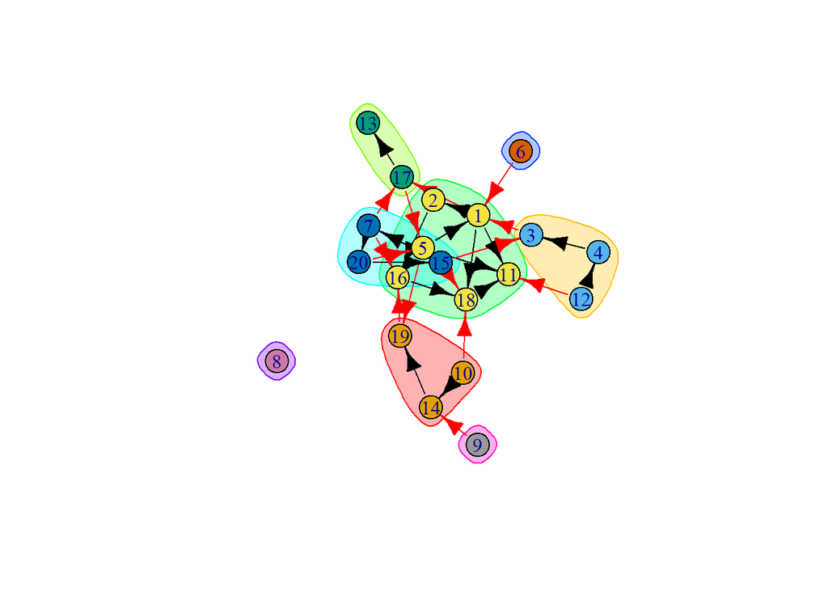

```r
# plot the network, highlighting the communities
plot(walk, g)
```

If you are so inclined, you can plot the community division as a dendrogram, as follows:

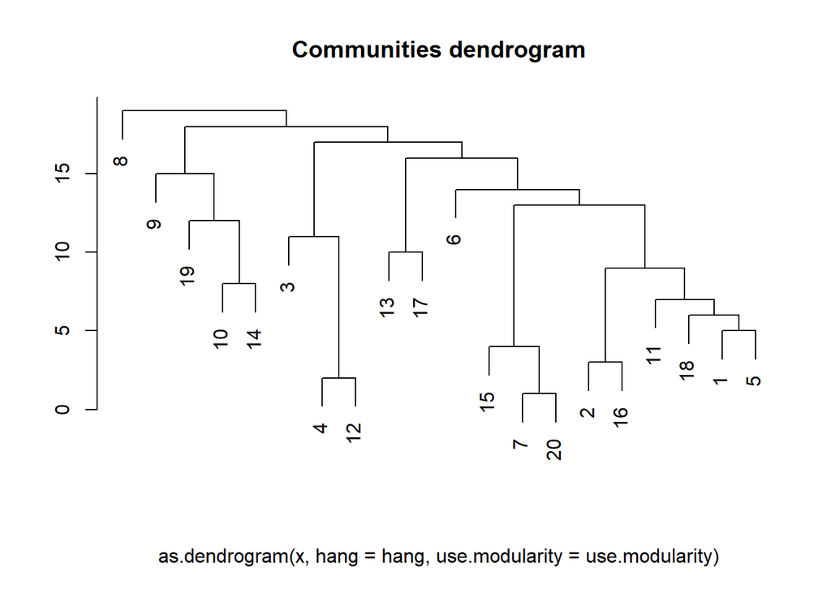

```r
snafun::plot_comm_dendrogram(walk)
```

# 6 Vertex-level indices

Here are the functions to determine many of the vertex-level indices you will want to use in this course.

Explore the vertices

Degree

snafun

```
v_degree(x, vids = NULL, mode = c("all", "out", "in"),
  loops = FALSE, rescaled = FALSE)
```

igraph

```
igraph::degree(g, mode = 'out')
```

network

```
sna::degree(g, gmode = 'digraph', cmode = 'outdegree')
```

Betweenness

snafun

```
v_betweenness(x, vids = NULL, directed = TRUE, rescaled = FALSE)
```

igraph

```
igraph::betweenness(g, directed = TRUE)
```

network

```
sna::betweenness(g, gmode = 'digraph', cmode = 'directed')
```

Flow betweenness

snafun

—

igraph

—

network

```
sna::flowbet(g, gmode = 'digraph', cmode = 'rawflow')
```

Bonacich power centrality

snafun

—

igraph

```
igraph::power_centrality(g)
```

network

```
sna::bonpow(g, gmode = 'digraph')
```

Closeness centrality

snafun

```
v_closeness(x, vids = NULL, mode = c("all", "out", "in"), rescaled = FALSE)
```

igraph

```
igraph::closeness(g, mode = 'all')
```

network

```
sna::closeness(g, gmode = 'digraph', cmode = 'directed')
```

Harmonic centrality

snafun

```
v_harmonic(x, vids = NULL, mode = c("all", "out", "in"), rescaled = FALSE)
```

igraph

```
harmonic_centrality(g, vids = V(graph),
  mode = c("out", "in", "all"), weights = NULL)
```

network

—

Stress centrality

snafun

```
v_stress(x, vids = NULL, directed = TRUE, rescaled = FALSE)
```

igraph

—

network

```
sna::stresscent(g, gmode = 'digraph', cmode = 'directed')
```

Eccentricity

snafun

```
v_eccentricity(x, vids = NULL, mode = c("all", "out", "in"), rescaled = FALSE)
```

igraph

```
igraph::eccentricity(g, mode = 'all')
```

network

—

Eigenvector

snafun

```
v_eigenvector(x, directed = TRUE, rescaled = FALSE)
```

igraph

```
igraph::eigen_centrality(g, directed = TRUE, scale = FALSE)$vector
```

network

```
sna::evcent(g, gmode = 'digraph', rescale=FALSE)
```

Page rank

snafun

```
v_pagerank(x, vids = NULL, damping = 0.85, directed = TRUE, rescaled = FALSE)
```

igraph

```
page_rank(g, vids = V(graph), directed = TRUE, damping = 0.85, weights = NULL)
```

network

—

Geo k-path

snafun

```
# without using weights
v_geokpath(x, vids = NULL, mode = c("all", "out", "in"),
  k = 3, rescaled = FALSE)

# if weights are to be used
v_geokpath_w(x, vids = NULL, mode = c("all", "out", "in"),
  weights = NULL, k = 3)
```

igraph

—

network

—

Shapley centrality

snafun

```
v_shapley(x, add.vertex.names = FALSE, vids = NULL, rescaled = FALSE)
```

igraph

—

network

—

Who are the neighbors of a vertex

snafun

```
extract_neighbors(x, vertex, type = c("out", "in", "all"))
```

igraph

```
igraph::neighbors(g, 'Jane', mode = 'out')

# all options
igraph::neighbors(graph, v, mode = c('out', 'in', 'all', 'total'))
```

network

```
network::get.neighborhood(g, 1, 'out')

# all options
network::get.neighborhood(x, v, type = c('out', 'in', 'combined'), na.omit = TRUE)
```

Neighborhood of a vertex<sup>1</sup>

snafun

—

igraph

```
igraph::make_ego_graph(g, order = 1, nodes = "Jane", mode = "all")

# all options
igraph::make_ego_graph(graph, order = 1, nodes = V(graph),
  mode = c("all", "out", "in"), mindist = 0)
```

network

```
sna::ego.extract(dat, ego = NULL, neighborhood = c("combined", "in", "out"))

sna::neighborhood(dat, order, neighborhood.type = c("in", "out", "total"),
  mode = "digraph", diag = FALSE, thresh = 0, return.all = FALSE, partial = TRUE)
```

<sup>1</sup> These functions serve equivalent purposes, but yield quite different kinds of outputs

# 7 Dyad-level indices

Here are the functions for several of the dyad-level indices you will want to use in this course.

Explore the dyads

shortest path for a given set of vertics

snafun

—

igraph

```
igraph::all_shortest_paths(g, from = IDofVertex, to = igraph::V(g), mode = 'out')
```

network

—

Geodesic lengths<sup>1</sup>

snafun

```
d_distance(x, mode = c("all", "out", "in"))
```

igraph

```
igraph::igraph::distances(g, mode = 'out')
```

network

```
sna::geodist(g, count.paths = TRUE)$counts
```

Structural equivalence

snafun

```
d_structural_equivalence(x, weights = NA, digits = 3, suppressWarnings = TRUE)
```

igraph

—

network

```
sna::sedist(g, method = "correlation", mode ="digraph", diag=FALSE)
```

Edge betweenness

snafun

—

igraph

```
igraph::edge.betweenness(g, directed = FALSE)
```

network

—

<sup>1</sup> The output is a table with an entry per vertex pair

# 8 Plotting

## 8.1 Plotting in `snafun`

The `snafun` package provides a `plot(x)` function, which allows the user to make a quick plot of a network, regardless of whether `x` is a graph of class `network` or `igraph`. This function wraps `network::plot.network` and `igraph::plot.igraph` and will use the default settings of these functions.

However, one can also use all of the arguments from `network::plot.network` and `igraph::plot.igraph` to make the plots nicer when wanted.

Here is an example for a `network` object.

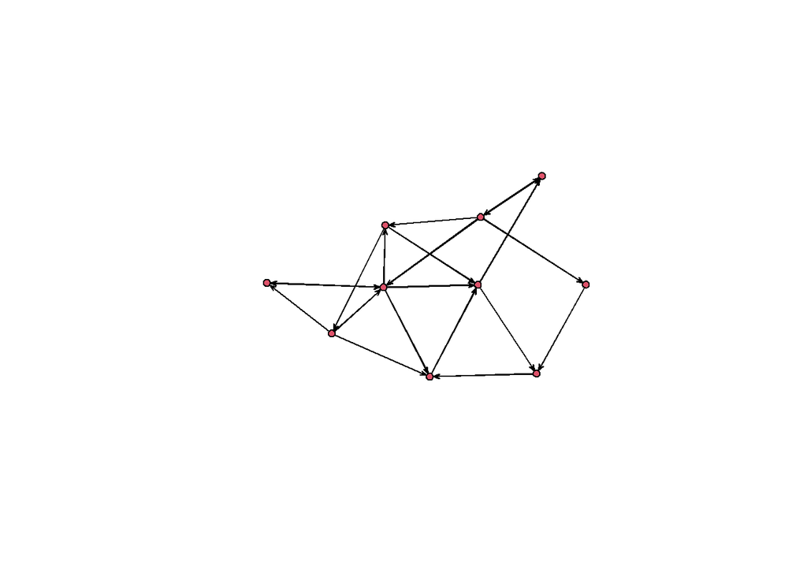

```r
g_n <- snafun::create_random_graph(10, "gnm", m = 20, graph = "network")
plot(g_n)
```

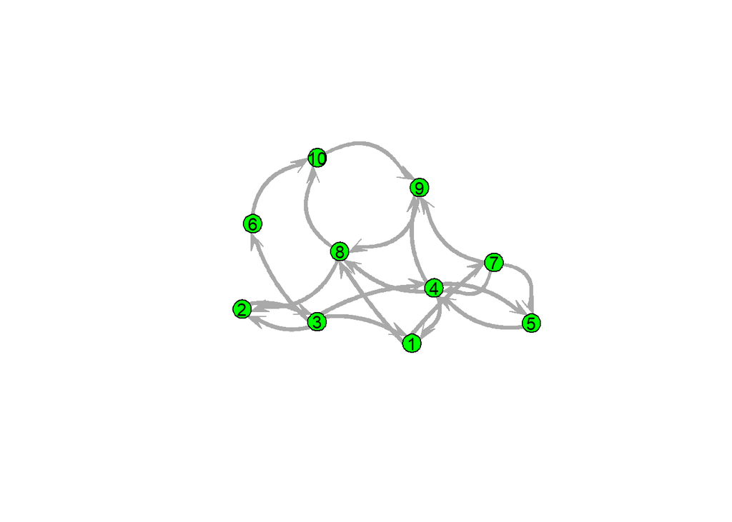

```r
plot(g_n, vertex.cex = 3, vertex.col = "green", edge.lwd = 10,
  edge.col = "darkgrey", usecurve = TRUE, edge.curve = .05,
  arrowhead.cex = 3, displaylabels = TRUE, label.pos = 5)
```

And for an `igraph` graph object:

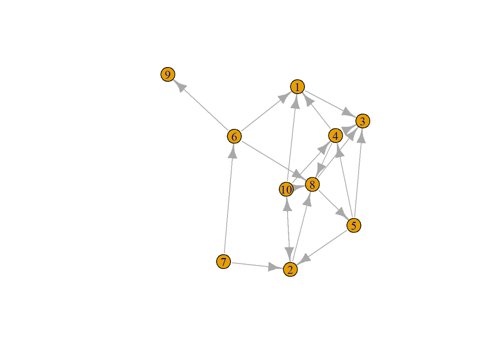

```r
g_i <- snafun::create_random_graph(10, "gnm", m = 20, graph = "igraph")
plot(g_i)
```

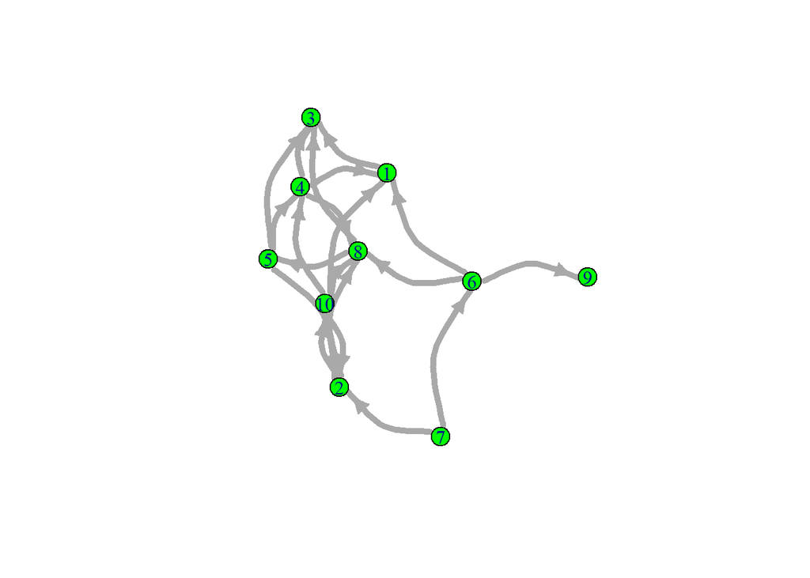

```r
plot(g_i, vertex.size = 12, vertex.color = "green", edge.width = 5, edge.curved = TRUE)
```

The most common use case for the function is to make as quick plot of the network, using default settings, as one usually would do in the initial phase of a study. For this, `snafun` provides a consistent function name.

The `snafun` package also contains a function to plot centrality scores of the vertices. The function and its options are specified as follows:

```r
snafun::plot_centralities(
  net,
  measures = c("betweenness", "closeness", "degree", "eccentricity"),
  directed = TRUE,
  mode = c("all", "out", "in"),
  k = 3,
  rescaled = FALSE,
  ...
)
```

This yields a plot like this:

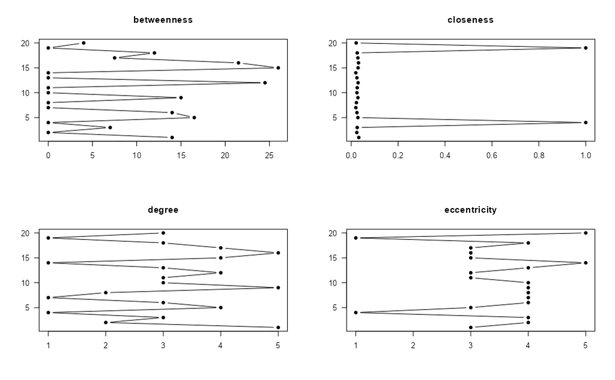

The function takes an object of class `igraph` or `network` and plots the centrality scores you select, so you can visually compare them. Make sure to pick the required value for `mode` (the default is “all”).

## 8.2 Basic plotting in `igraph`

The `plot` function alone already plots nodes and edges with default options. More sophisticated specifications need to be manually set. It works with networks of class `igraph`.

```r
plot(net,
     edge.arrow.size = .2,                # edge and arrow size
     edge.color = "red",                  # edge color
     vertex.color = "blue",               # vertex filling color
     vertex.frame.color = "green",        # vertex perimeter color
     vertex.label = igraph::V(net)$label, # vertex labels
     vertex.label.cex = 0.6,              # vertex label size
     vertex.label.color = "black")        # vertex label color
```

## 8.3 Basic plotting in `network`

The `gplot` function alone already plots nodes and edges with default options. More sophisticated specifications need to be manually set. It works with networks of class `network`.

```r
gplot(net,
      arrowhead.cex = 0.2,     # edge and arrow size
      edge.col = 'red',        # edge color
      vertex.col = 'blue',     # vertex filling color
      vertex.border = 'green', # vertex perimeter color
      displaylabels = TRUE,    # vertex labels
      label.cex = 0.6,         # vertex label size
      label.col = 'black')     # vertex label color
```

# 9 Statistical models

## 9.1 Overview table

Here is an overview of the statistical models discussed in the course.

Statistical network models

When

Which approach

Function

Dependent vertex attribute explained by a network weight matrix and a matrix of covariates

Network autocorrelation model

```
sna::lnam
```

A statistic on a single network

Conditional Uniform Graph test

```
sna::cug.test
```

Association between two networks

QAP

```
sna::qaptest
```

A valued dependent network explained by one or more explanatory networks

QAP linear model

```
sna::netlm
```

A binary dependent network explained by one or more explanatory networks

QAP logistic model

```
sna::netlogit
```

A binary or valued dependent network explained by a set of endogenous and exogenous variables

Exponential random graph models

```
ergm::ergm
```

## 9.2 Network autocorrelation models

The network autocorrelation model is run through the `sna::lnam` function. The basic function call is as follows:

```r
sna::lnam(y, x = NULL, W1 = NULL, W2 = NULL)
```

Here,

- `y` is a vector with a value for each vertex. The implementation in `sna::lnam` is only appropriate for continuous dependent variables.
- `W` is a matrix of the same dimension as the network, containing the weights that drive the network influence process. You need to specify `W1` for the network effects model. Include weight matrix `W2` if you want to run a network disturbances model.
- `x` is a matrix with a row per vertex. Make sure to include a column with 1’s into `x`, so an intercept is included. Make sure to include column names as well, so you get informative output.

In `sna` there is a useful `summary` method (that shows you an overview of the results) and a `plot` method (that you use to check model assumptions).

## 9.3 Conditional Uniform graphs (CUG)

There are two methods to perform a conditional Uniform graph test.

The first is to generate the graphs manually and calculate the measures on each graph. Generation of these graphs can be done using `snafun::create_random_graph` (which conditions on size and density). The equivalent functions in `sna` are `sna::rgraph` and `sna::rgnm` (note that these generate a matrix, rather than an `igraph` or `network` graph). See the data generation table for these functions.

The second approach is to use a function that does the graph generation and computes the network measure for you. The preferred is `sna::cugtest`, which is specified as follows:

```r
sna::cug.test(g, FUN, mode = c("digraph", "graph"), cmode = c("size",
    "edges", "dyad.census"), reps = 1000,
    ignore.eval = TRUE, FUN.args = list())
```

See the `sna` help function for details.

Here

- `FUN` is the function that needs to be calculated on each graph
- `FUN.args` contains any arguments that are required for the function you specified in `FUN`
- `cmode` determines the type of graphs that are drawn (ie. what you condition on). The options are
  - “size”: this generates graphs with a particular size and density 0.5. You rarely want this.
  - “edges”: this conditions on a specific edge count (or an exact edge value distribution)
  - “dyad.census”: this conditions on a dyad census (or dyad value distribution)

For example, in order to test whether the transitivity in your graph `g` is exceptional for a network of the same size and density as in `g`, you would run

```r
sna::cug.test(g, sna::gtrans, cmode = "edges")
```

It is wise to always explicitly tell the function whether your graph is directed or not, so a better way to specify the previous function is

```r
sna::cug.test(g, mode = "graph", FUN = sna::gtrans,
              cmode = "edges", reps = 1000,
              FUN.args = list(mode = "graph"))
```

Testing the betweenness centralization of you network `g` could be performed as follows, again conditioning on size and density:

```r
sna::cug.test(g,
              sna::centralization,
              FUN.arg=list(FUN = sna::betweenness),
              mode="graph",
              cmode="edges")
```

There is also a useful `plot` method for the result of the CUG test.

## 9.4 QAP test

There are two methods to perform a QAP test.

The first is to manually permute the graph. Generation of these graphs can be done using `igraph::permute` or `sna::rmperm`. See the data generation table for these functions.

The second approach is to use a function that does the graph permutation and computes the required measure (typically a correlation) for you. The preferred is `sna::qaptest`, which is specified as follows:

```r
sna::qaptest(g, FUN, reps = 1000, ...)
```

See the `sna` help function for details.

Here

- `FUN` is the function that needs to be calculated after each permutation
- `...` contains any arguments that are required for the function you specified in `FUN`

Typically, you want to test the correlation between two graphs, as follows:

```r
sna::qaptest(list(firstNetwork, secondNetwork),
             FUN = sna::gcor, reps = 1000,
             g1 = 1, g2 = 2)
```

There is a useful `summary` method and a `plot` method for the output of the function.

## 9.5 QAP linear regression

QAP linear regression is performed through the `sna::netlm` function. The function looks as follows:

```r
sna::netlm(y, x, intercept = TRUE, mode = "digraph",
    nullhyp = "qapspp", reps = 1000)
```

Make sure to always set `intercept = TRUE` and `nullhyp = "qapspp"`. For small networks, 1000 replications should be enough, for larger networks you should typically use a higher number (say, 2000).

As an example, this is how you specify a model where graph `g` is modeled as a linear function of graphs `g1`, `g2`, and `g3`.

```r
mod <- sna::netlm(y = g, x = list(g1, g2, g3), intercept = TRUE,
                              nullhyp = 'qapspp', reps = 1001)
mod$names <- c("Intcpt", "Net1", "Net2", "Net3")
summary(mod)
```

It is wise to add the names of the networks to the output object, like you see above. That is not strictly necessary, but it makes the output of the function easier to read.

## 9.6 QAP logistic regression

QAP logistic regression is performed through the `sna::netlogit` function. The function looks as follows:

```r
sna::netlogit(y, x, intercept = TRUE, mode = "digraph",
    nullhyp = "qapspp", reps = 1000)
```

Make sure to always set `intercept = TRUE` and `nullhyp = "qapspp"`. For small networks, 1000 replications should be enough, for larger networks you should typically use a higher number (say, 2000).

As an example, this is how you specify a model where binary graph `g` is modeled as a function of graphs `g1`, `g2`, and `g3`.

```r
mod <- sna::netlogit(g, list(g1, g2, g3),
                     intercept = TRUE,
                     nullhyp = "qapspp", reps = 1001)
mod$names <- c("Intcpt", "Net1", "Net2", "Net3")
summary(mod)
```

## 9.7 Terms classification for every Exponential Random Graph Model (ERGM)

Terms can be classified in six main ways.

- Dyadic independent and dyadic dependent terms: We encounter the first one when the probability of edge formation is related to nodes properties or attributes; we encounter the second when the probability of edge formation depends on other existing edges.
- Structural and nodal attributes terms: The first kind provides tools to understand the structure of the network per se; the second kind provides tools to explain how nodal attributes might have influenced the formation of edges.
- Terms for directed networks and terms for undirected networks
- Exogenous and Endogenous terms: The first one refers to terms using covariates, the second to structural terms.
- Markovian or non-Markovian: a Markovian term measures the structure in a network neighborhood
- Curved (geometrically weighted ) or non-curved: terms that are tweaked to improve the model stability

## 9.8 Binary Exponential Random Graph Model (ERGM)

An ERGM model is performed through the `ergm::ergm` function. The basic function call is as follows:

```r
fit <- ergm::ergm(formula)
```

The formula requires the specification of a network dependent variable, and a list of terms.

### 9.8.1 Most popular structural/endogenous - dyadic independent terms

- `edges` Extent to which the number of edges in the network characterizes the overall structure (Is it a random number of edges, or it is the meaningful outcome of a certain phenomenon?). Introduces one statistic to the model. Directed and Undirected networks.
- `density` Extent to which the network density characterizes the overall structure (Is it a random density, or it is the meaningful outcome of a certain phenomenon?). Introduces one statistic to the model. Directed and Undirected networks.
- `sender` Extent to which a specific node, compared to a baseline one, is sending out non-random edges (different from the same node’s behavior in a random distribution). Introduces to the model as many statistics as the number of nodes minus one. Directed Networks only.
- `receiver` Extent to which a specific node, compared to a baseline one, is receiving non-random edges (different from the same node’s behavior in a random distribution). Introduces to the model as many statistics as the number of nodes minus one. Directed Networks only.

### 9.8.2 Most popular structural/endogenous/Markovian - dyadic dependent terms

- `mutual` Extent to which ties are more likely to be reciprocated than they would be in a random network (controlling for the other effects). Introduces one statistic to the model. Directed networks only.
- `asymmetric` Extent to which the observed non reciprocated ties are non-random. Introduces one statistic to the model. Directed networks only.
- `triangles` Extent to which the observed triangles are non-random. Introduces one statistic to the model. Directed and Undirected networks. In the case of directed network measures “transitive triple” and “cyclic triple”, so triangle equals to `ttriple` plus `ctriple`.
- `triadcensus` Extent to which the sixteen categories in the categorization of Davis and Leinhardt (1972) are observed in the network and are not generated at random. Introduces 16 statistics to the model. Directed networks only.

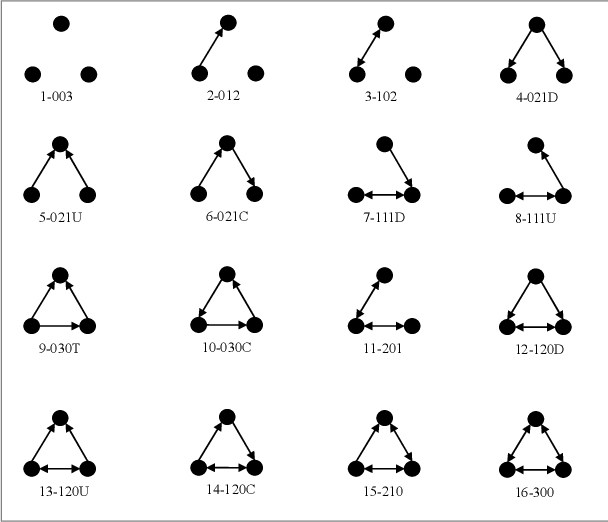

Triad Census

- `balance` Extent to which type 102 or 300 in the categorization of Davis and Leinhardt (1972) -balanced triads- observed in the network are non-random. Introduces one statistic to the model. Directed networks only.
- `transitive` Extent to which type 120D, 030T, 120U, or 300 in the categorization of Davis and Leinhardt (1972) -transitive triads- observed in the network are non-random. Introduces one statistic to the model. Directed networks only.
- `intransitive` Extent to which type 111D, 201, 111U, 021C, or 030C in the categorization of Davis and Leinhardt (1972) -intransitive triads- observed in the network are non-random. Introduces one statistic to the model. Directed networks only.
- `degree(n)`, `idegree(n)`, `odegree(n)` Extent to which nodes with a specified degree are non random. Introduces one statistic to the model. Directed and Undirected networks, with the possibility of `in` and `out` specifications for Directed networks.
- `kstar(n)`, `istar(n)`, `ostar(n)` Extent to which stars connecting the specified number of nodes are non random. Introduces one statistic to the model. Directed and Undirected networks, with the possibility of `in` and `out` specifications for Directed networks.
- `cycle(n)` Extent to which cycles with a specified number of nodes are non-random. Introduces one statistic to the model. Directed and Undirected networks.

### 9.8.3 Most popular structural/endogenous/curved - dyadic dependent terms

- `gwesp(decay=0.25, fixed=FALSE)` Geometrically weighted edgewise shared partner distribution. It can be used in place of triangles to improve convergence. The decay parameter should be non-negative. The value supplied for this parameter may be fixed (if `fixed=TRUE`), or it may be used instead as the starting value for the estimation of decay in a curved exponential family model (when `fixed=FALSE`, the default) (see Hunter and Handcock, 2006). This term can be used with directed and undirected networks. For directed networks, only outgoing two-path (`“OTP”`) shared partners are counted.
- `dgwesp(decay=0.25, fixed=FALSE, type= 'RTP')` Geometrically weighted edgewise shared partner distribution. It also counts other types of shared partners not covered by `gwesp`: Outgoing Two-path (`“OTP”`), Incoming Two-path (`“ITP”`), Reciprocated Two-path (`“RTP”`), Outgoing Shared Partner (`“OSP”`), Incoming Shared Partner (`“ISP”`).
- `gwdegree(decay, fixed=FALSE, attr=NULL, cutoff=30, levels=NULL)`, `gwidegree(.5,fixed=T)`, `gwodegree(.5,fixed=T)` Geometrically weighted degree distribution. It can be used in place of `degree(n)` to improve convergence. Introduces one statistic to the model equal to the weighted degree distribution with decay controlled by the decay parameter. Directed and Undirected networks, with the possibility of `in` and `out` specifications for Directed networks.

### 9.8.4 Most popular nodal covariate terms

- `nodecov`, `nodeicov`, `nodeocov` Numeric or Integer attributes. Extent to which the attribute values influence edge formation (same as in a logit model) so that it is non-random under that condition. Introduces one statistic to the model. Directed and Undirected networks, with the possibility of `in` and `out` specifications for Directed networks. Dyadic independent.
- `nodefactor`, `nodeifactor`, `nodeofactor` Categorical attributes. Extent to which nodes characterized by a specific category form more ties, so that tie formation is non-random under that condition. Introduces to the model a number of statistics equal to the number of categories minus one. Directed and Undirected networks, with the possibility of `in` and `out` specifications for Directed networks. Dyadic independent.
- `absdiff` Numeric or Integer attributes. Extent to which common features measured in terms of distance similarity influence edge formation, so that edge formation is non-random under that condition. Introduces one statistic to the model. Directed and Undirected networks. Dyadic independent.
- `nodematch` Categorical attributes. Extent to which nodes characterized by a specific category belonging to a certain attribute form ties with other node characterized by the same category, so that tie formation under that condition is non-random. Introduces to the model as many statistics as the number of categories. Directed and Undirected networks. Dyadic independent. —Differential homophily
- `edgecov` Matrix attribute. Extent to which the ties formed in another context influence tie formation in the context of the current model, so that tie formation under that circumstances is non-random. Introduces one statistic to the model. Directed and Undirected networks. Dyadic dependent.
- `nodemix` Categorical attributes. Extent to which nodes denoted by different categories of an attribute form ties, so that tie formation under these circumstances is non-random. Introduces as many statistics as the number of combinations between every two categories. Directed and Undirected networks. Dyadic independent.

### 9.8.5 Terms specifications

Use the argument `levels` within the term specification for selecting the baseline or reference category.

Example: set female as a reference category.

```r
fit <- ergm::ergm(Net ~ edges + nodefactor('sex', levels = -(2)))
```

### 9.8.6 Searching for terms

You can look for additional terms with

```r
search.ergmTerms(keyword, net, categories, name)
```

You have four arguments to help you finding terms:

- `keyword` optional character keyword to search for in the text of the term descriptions. Only matching terms will be returned. Matching is case insensitive.
- `net` a network object that the term would be applied to, used as template to determine directedness, bipartite, etc
- `categories` optional character vector of category tags to use to restrict the results (i.e. ‘curved’, ‘triad-related’) –see categorization of terms in the manual
- `name` optional character name of a specific term to return

### 9.8.7 Checking your data before the analysis

Before you run any exponential random graph model you must know your data by heart. Not only using descriptive network statistics, but also checking model specifications, before hitting the run button.

- Manually check the attribute(s) (numeric, integer, categorical, ordinal)

```r
table(snafun::extract_vertex_attribute(Net, 'sex'))
```

- check mixing of categorical attributes

```r
snafun::make_mixingmatrix(Net, "sex")
```

- check model statistics.

```r
summary(Net ~ edges + nodefactor('sex'))
```

This last one provides the number of observed cases under the assumptions of each term.

### 9.8.8 Reading results

You interpret ERGM results as logit models results. Two options:

- Compute odd ratios for each coefficient

```r
OR <- exp(coef)
```

- Compute probability for each coefficient

```r
P <- exp(coef) / (1 + exp(coef))
```

- Compute odd ratios using the `SNA4DS` function

```r
OR <- snafun::stat_ef_int(m)
```

- Compute probability using the `snafun` function

```r
P <- snafun::stat_ef_int(m, type = "probs")
```

### 9.8.9 Simulating networks

It is sometimes helpful to simulate networks with the same features at the one you observed in real life.

- Simulating a network from a model

```r
fit <- ergm::ergm(Net ~ edges)
simfit <- simulate(fit, burnin = 1e+6, verbose = TRUE, seed = 9)
```

- simulate network fixing the coefficient results

```r
RandomNet <- network::network(16,density=0.1,directed=FALSE)

sim <- simulate(~ edges + kstar(2), nsim = 2, coef = c(-1.8, 0.03),
                  basis = RandomNet,
                  control = ergm::control.simulate(
                    MCMC.burnin=1000,
                    MCMC.interval=100))
sim[[1]]
```

### 9.8.10 MCMC Diagostics

You can check the Monte Carlo Markov Chains diagnostic for your dyadic dependent model using the function:

```r
ergm::mcmc.diagnostics(fit)
```

### 9.8.11 Goodness of Fit

You can check the goodness of fit of your model using the function

```r
ergm::gof(fit)
```

You can also plot your `gof` output

```r
plot(ergm::gof(fit))
```

or, making use of your new best friend (the `snafun` package):

```r
snafun::stat_plot_gof(fit)
stat_plot_gof_as_btergm(fit)
```

## 9.9 Bipartite ERGMs

A bipartite ERGM works exactly the same way as a binary one. However, in order to make it handle data differentiating between two partitions, it is necessary to use some specially defined terms. Moreover, you will need to specify the model with more advanced settings since it is computationally more demanding.

### 9.9.1 Importing Bipartite ERGMs

Since you are using the same function as binary ERGM (`ergm::ergm`) to run the model, it is necessary to make sure that the software knows that it needs to handle a bipartite structure.

#### 9.9.1.1 Step one: Specify the incidence matrix

The data that contains bipartite network information needs to be specified into a partition 1 X partition 2 data frame or matrix.

If 10 people attend 4 events, the incidence matrix will have dimensions 10 X 4.

#### 9.9.1.2 Step two: Import the network as a bipartite

You can import the network as bipartite using these specifications.

```r
BipNet <- network::network(BipData, directed = FALSE, bipartite = TRUE)
```

#### 9.9.1.3 Step three: Import the attributes

You can import the attributes using this code. The attribute vector needs to contain as many elements as Partition 1 + Partition 2. However, it is unlikely to have an attribute that makes sense for both partitions at the same time.

Make sure to insert the information that concerns partition 1 and afterward the information that concerns partition 2.

Make sure to code as `NA` the entry for the partition for which you do not have information.

For instance, if we have one attribute for partition one in a network with 10 nodes in partition 1 and 4 in partition 2, we will have the first ten digits storing information about nodes in partition 1 and 4 NAs for partition 2.

```r
# vertex.names <- vector of names
attrib1 <- as.character(c(0, 0, 0, 0, 0, 1, 1, 1, 1, 1, NA, NA, NA, NA))

snafun::add_vertex_attributes(BipNet, "vertex.names",  vertex.names)
snafun::add_vertex_attributes(BipNet, "attrib1",  attrib1)
```

#### 9.9.1.4 Step four: Bipartite extra info

In order to make sure that the software correctly reads your bipartite network, you need to code an extra attribute.

The attribute focuses on partition one. For example, if we have 10 nodes in partition 1 we will use:

```r
snafun::add_vertex_attributes(BipNet, "bipratite", value = rep(10, 10), v = 1:10)
```

Note: `bipratite`, yes, it is a typo, but a typo in the package. Hence make sure you misspell it; otherwise, you will get an error. (FUN FACT!)

### 9.9.2 Terms for Bipartite ERGMs

Bipartite ERGMs terms are provided at the same time for both partitions since it is relevant to consider the same structure from both perspectives.

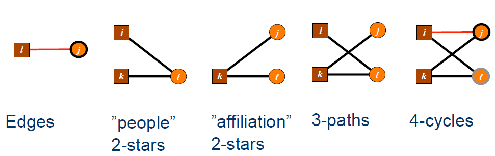

You can find the full list of bipartite terms by running:

```r
ergm::search.ergmTerms(categories = "bipartite")
```

They are 32 in total, so it is manageable.

#### 9.9.2.1 The most popular terms are:

- `b1star(k)` & `b2star(k)` – `star(k)` for binary ERGMs
- `gwb1dsp()` & `gwb2dsp()` – same as `gwdsp()` for binary ERGMs
- `b1cov` & `b2cov` – same as `nodecov()` for binary ERGMs
- `b1factor` & `b2factor` – same as `nodefactor()` for binary ERGMs
- `b1nodematch` & `b2nodematch` – same as `nodematch()` for binary ERGMs

### 9.9.3 Specifying advanced options

Since a bipartite ERGM is computationally more demanding than a regular one, you need to make sure you specify the advanced options offered by the `ergm` package.

#### 9.9.3.1 Constraints

Constraints are options that allow you to set limits your simulation takes into account

For instance, you can limit the simulation setting a min and a max degree.

`constraints= ~ bd(minout = 0, maxout = 7)`

For instance,

```r
m <- ergm::ergm(BipNet ~ edges  + b1factor("attr1", levels = -1) + b1star(2),
                 constraints= ~ bd(minout = 0, maxout = 7))
```

There are many other constraints that it is possible to use

#### 9.9.3.2 Control

Controls are options that allow you to be aware of what your simulation is doing to a larger extent and, for this reason, to make it faster.

There are several options. For instance,

- `MCMC.burnin` - ignore than many chains before starting to estimate parameters
- `MCMC.samplesize` - collect that number of information from the previous state in order to inform the following one
- `seed` - makes the simulation go the same way every time it is run
- `MCMLE.maxit` - breaks the algorithm after that number of attempts.

For instance,

```r
m <- ergm::ergm(BipNet ~ edges  + b1factor("attr1", levels = -1) + b1star(2),
                 constraints= ~ bd(minout = 0, maxout = 7),
                 control = ergm::control.ergm(MCMC.burnin = 5000,
                                              MCMC.samplesize = 10000,
                                              seed = 1234,
                                              MCMLE.maxit = 20))
```

## 9.10 Weighted ERGMs

A weighted network is a network where the edges express the weight or the intensity of the relationship.

It is still unimodal, but it contains more information.

In order to use weighted ergms, the network needs to be fully connected.

Different kinds of weights require different models. You need to check:

- what kind of variable type characterizes your weights (integer, count, numeric, ordinal…)
- what kind of distribution does your weight have

The `GERGM` package works with fully connected networks and (theoretically ) every kind of weight variable.

The `GERGM` package does not recognize either the `network` or the `igraph` classes.

You need to work with weighted adjacency matrices (NxN - squared, that has inside the weight, rather than 0s and 1s).

### 9.10.1 Documentation

Installation:

`remotes::install_github("matthewjdenny/GERGM", dependencies = TRUE)`

User manual

`https://github.com/matthewjdenny/GERGM`

Vignette

Run `browseVignettes("GERGM")`in the R console

### 9.10.2 Most popular endogenous terms (Markovian and Curved)

- `twostars`, equivalent to `star(2)` in `ergm`
- `out2stars`, equivalent to `ostar(2)` in `ergm`
- `in2stars`, equivalent to `istar(2)` in `ergm`
- `ctriads`, same as in `ergm`
- `mutual`, same as in `ergm`
- `ttriads`, same as in `ergm`

Convergence problems? Use exponential down-weighting. AKA “curve” the terms:

E.g., `out2stars(alpha = 0.25)` - default = 1

### 9.10.3 Most popular exgenous terms

- `absdiff(covariate = "MyCov")`
- `sender(covariate = "MyCov")` – different from `ergm`, here you can insert an attribute
- `receiver(covariate = "MyCov")` – different from `ergm`, here you can insert an attribute
- `nodematch(covariate = "MyCov", base = "Ref.cat")`
- `nodemix(covariate = "MyCov", base = "Ref.cat")`
- `netcov(network)` – like `edgecov` in `ergm`

### 9.10.4 Running the model

First, we specify the formula,

```r
formula <- adjacencyMatrix ~ edges +
  sender("myCov") +
  receiver("myCov") +
  netcov(otherAdjMat) +
  mutual(alpha = .9)
```

Then we run the model

```r
set.seed(5)
gergmResults <- GERGM::gergm(formula,
                      estimation_method = "Metropolis", # chose the algorithm to estimate the model
                      covariate_data = covariateData, # passing attributes on
                      number_of_networks_to_simulate = 100000, # same as ergm
                      MCMC_burnin = 10000, # same as ergm
                      thin = 1/10, # retaining only a small number of simulated Networks in the computer memory
                      transformation_type = "Cauchy") # distribution of the weight
```

The `GERGM::gergm` function automatically prints results while it runs. However, it is also possible to print them again separately.

#### 9.10.4.1 Plotting MCMC diagnostics

`GERGM::Trace_Plot(gergmResults)`

#### 9.10.4.2 Plotting the Goodnes of fit

`GOF(gergmResults)`

#### 9.10.4.3 Plotting the results

`GERGM::Estimate_Plot(gergmResults)`

#### 9.10.4.4 Printing a table with standard errors and coefficients

```r
(EstSE <- rbind(t(attributes(gergmResults)$theta.coef),
                t(attributes(gergmResults)$lambda.coef)))
```

#### 9.10.4.5 Significance

`GERGM` models use confidence intervals instead of p-values.

You can estimate the confidence interval using this formula

```r
lower = coef - SE*(-qnorm((1 - 0.95)/2))
upper = coef + SE*(-qnorm((1 - 0.95)/2))
```

If the lower and the upper intervals are both negative or both positive, the coefficient is significant.

If the lower and the upper intervals have different sign, the coefficient is not significant.

## 9.11 ERGM for temporal networks

The TERGM (=Temporal ERGM) can be used to model a sequence of **binary** networks. The model is very similar to the ERGM, but the dependent variable is now a list of networks: the first element is the network at time 1, the second element is the network at time 2, et cetera.

### 9.11.1 How to store the data for a TERGM

You store the data needed for fitting a TERGM as follows.

| What | How to store |
| --- | --- |
| Time-varying dyadic covariates | Either as a list of networks or matrices |
| Constant dyadic covariates | Single network or matrix |
| Vertex level attributes | As vertex attributes inside the observed network objects |

### 9.11.2 How to fit a TERGM

You fit a TERGM with the `btergm` package (to be installed from CRAN). This fits the model with MPLE, using bootstrapping to derive the standard errors.

The `btergm` package is compatible with the `ergm` package and you can use the terms from that package inside `btergm`.

There are three groups of temporal measures you can specify: `memory`, `delayed reciprocity`, and `time covariates`.

Temporal effects for the ERGM

meaning

btergm

memory

Positive autoregression

Previous existing edges persist in a next network

```
 btergm::memory(type = "autoregression", lag = 1)
```

Dyadic stability

Both previous existing and non-existing ties are carried over to the current network

```
 btergm::memory(type = "stability", lag = 1)
```

Edge innovation

A non-existing previous tie becomes existent in the current network

```
 btergm::memory(type = "innovation", lag = 1)
```

Edge loss

An existing previous tie is dissolved in the current network

```
 btergm::memory(type = "loss", lag = 1)
```

delayed reciprocity

reciprocity

if node j is tied to node i at t = 1, does this lead to a reciprocation of that tie back from i to j at t = 2?

```
 btergm::delrecip(mutuality = FALSE, lag = 1)
```

mutuality

if node j is tied to node i at t = 1, does this lead to a reciprocation of that tie back from i to j at t = 2 AND if i is not tied to j at t = 1, will this lead to j not being tied to i at t = 2? This captures a trend away from asymmetry.

```
 btergm::delrecip(mutuality = TRUE, lag = 1)
```

time covariates

time effect per se

Test for a specific trend (linear or non-linear) for edge formation

```
 btergm::timecov(transform = function(t) t)
```

Time effect of a covariate

Interaction effect to test whether the importance of a covariate increases or decreases over time

```
 btergm::timecov(x, transform = function(t) t)
```

Visually:

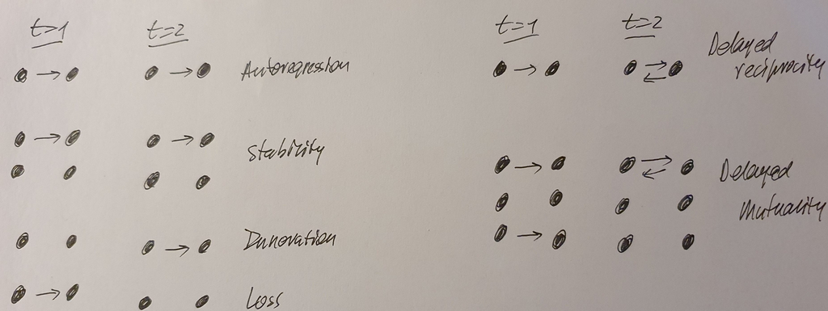

When a `timecov` is specified without including the value for the `transform`, the specification defaults to a linear trend over time. For example: `timecov()` (= the effect of time per se) or `timecov(militaryDisputes)` (= a linearly increasing or decreasing effect of `militaryDisputes` over time).

### 9.11.3 Parallel processing

The `btergm` package uses MPLE and that lends itself well to parallel processing. You specificy that you want to use parallel processing using the argument `parallel`.

Windows users can only use `parallel = "snow"`. Other systems can use either `parallel = "snow"` or `parallel = "multicore"`. The latter is probably often the better choice for non-Windows machines. Both options require that you have the `parallel` package installed.

If you use the `parallel` option, you should also specify the appropriate number of cores you want to use. Either set `ncpus = 4` (for four cores) or use `ncpus = parallel::detectCores()` to have R recognize the number of cores automatically (this usually works well, but not always). The `ncpus` argument is ignored if you do not specify the `parallel` argument.

The default is no parallel processing.

### 9.11.4 Goodness-of-fit

Goodness of fit is determined by

`gof_m <- btergm:::gof.btergm(m, statistics = btergm_statistics)`, where

Of course, the more statistics you include (and the more complex the statistics), the more time it will take for the GoF calculations to finish.

Use `` ?btergm:::`gof,btergm-method` `` for more options.

The GoF object can be plotted using `btergm:::plot.gof(gof_m)`. More convenient is to use the helper function from the `snafun` package. This is:

`gof_m <- snafun::stat_plot_gof_as_btergm(m)`

By default, this includes the statistics `c(btergm::esp, btergm::geodesic, btergm::deg, btergm::rocpr)` in the goodness-of-fit, but you can specify other statistics if you prefer. The function returns the goodness-of-fit (in this case, in the `gof_m` object) and plots it as well. This prevents you from having to use the triple colon `:::` for `btergm:::gof.btergm` and is generally more convenient. If you need the full flexibility of the `btergm:::gof.btergm` function, use that directly. The results between the two functions are identical.

If you include the `btergm::rocpr` “statistic” in your GoF, the red line is the Receiver Operating Characteristic (ROC) curve and the blue line is the Precision-Recall curve.

If you see value in the ROC or PR, you can find the arreas under the curves using `` gof_m$`Tie prediction`$auc.roc `` and `` gof_m$`Tie prediction`$auc.pr ``. Note that Precision-Recall is most appropriate for sparse networks, while ROC works well for more connected networks. Either way, the plots for the network statistics are generally much more informative compared to ROC and PR (because the ROC and PR) don’t take the dependency structure in your data into account.

In the other plots, the grey boxplots represent the distribution of the values from the observed networks, the thick black line is the median of the simulations and the dashed line is the mean of the simulations. You can suppress the median by plotting using:

`plot(gof_m, median = FALSE)`

Note: you can also feed a fitted ERGM model to

`snafun::snafun::stat_plot_gof_as_btergm(m)`

and determine the goodness-of-fit for the fitted ERGM that way.

# 10 Temporal networks (exploration and description)

The main packages to use in this course for descriptive and exploratory analysis of temporal networks are `networkDynamic` to construct and manipulate temporal networks), `tsna` (for `sna`-like network measures), and `ndtv` (for visualization).

Edges will typically have a starting time (`onset`), and end time (`terminus`), a duration, a sender (`tail`), and a receiver (`head`). of course, edges can start and end multiple times during the observation period and can have durations of length 0 up until any positive number.

The temporal networks are of class `networkDynamic`.

## 10.1 Network generation and manipulation

- `networkDynamic::networkDynamic`: construction of a temporal network. There are many ways in which you can construct a temporal network. A common way is to first construct a network that has the vertex names, any vertex static attributes, edge attributes, whether the network is directed, et cetera.  
  This network is called `base.net` and is used by this function to extract the basic aspects of the network. Don’t worry that some values (e.g., vertex attributes) may change over time, because any temporal info you add to this function will override what is in `base.net`. But `base.net` is an excellent and efficient way to provide much data to the function about the temporal network and it more cumbersome to add that later on.  
  Further, you can provide dynamic data through `data.frame`s for vertices and for edges in several ways. Consult the `help` function for the details, as this vignette would become far too long otherwise.
- `as.data.frame(g)` Extract the dynamic edge info from the network, as a `data.frame`.

Most of the functions below allow you to specify a time segment you are interested in. Typically, these include `onset`, `terminus`, `length`, and `at`. Below, we give only one example of how each function can be specified.

- `networkDynamic::list.vertex.attributes.active(g, onset = 5, terminus = 8)` List the attributes of the vertices that are active in a specific time segment.
- `networkDynamic::get.vertex.attribute.active(g, "attrName", at = 1)` The value for vertex attribute `attrName` in a specific time segment.
- `networkDynamic::list.edge.attributes.active(g, onset = 0, terminus = 49)` List the attributes of the edge that are active in a specific time segment.
- `networkDynamic::get.edge.attribute.active(g, "attrName", at = 1)` The value for edge attribute `attrName` in a specific time segment.
- `networkDynamic::network.extract(classroom, onset = 0, terminus = 1)` Extract the part of the temporal network for a specific time segment.
- `networkDynamic::network.collapse(classroom, onset = 0, terminus = 1)` Collapse the temporal network into a static network based on the activity within a specific time segment.
- `networkDynamic::activate.vertex.attribute`, `networkDynamic::activate.edge.attribute`, `activate.edge.value`, `activate.network.attribute` Set or modify attributes within a specific time segment.
- `deactivate.vertex.attribute`, `deactivate.edge.attribute`, `deactivate.network.attribute` Make an attribute inactive during a specific time segment.

NOTE: The functions above for accessing and setting the attributes of a `networkDynamic` object are not very user friendly. Luckily, you can also access and/or set attributes using the `network` package or the `snafun` package like in the network manipulation table. As long as you want to access and/or set attributes that are *static*, this works much easier and uses functions that you have used multiple times already in this course and should be second nature to you by now.

## 10.2 Network measures and descriptives

- `networkDynamic::duration.matrix(g, changes, start, end)` This function takes a given temporal network `g`, a matrix with columns “time”, “tail”, “head” (this matrix is called a *toggle list*), and a start and end time. It returns a `data.frame` a list of edges and activity spells. A toggle represents a switch from active state to inactive, or vice-versa.
- `network.size(g, onset = 5, length = 10)`. The size of a network during a specific time segment.

The following functions provide useful descriptives of durations in the temporal network.

- `tsna::edgeDuration(g, mode = "duration")` or `tsna::edgeDuration(g, mode = "counts")` Sums the activity duration or number of edge events in a time segment.
- `tsna::vertexDuration(g, mode = "duration")` or `tsna::vertexDuration(g, mode = "counts")` Sums the activity duration or number of vertex events in a time segment.
- `tsna::tiedDuration(g, mode = "duration")` Measures the total amount of time each vertex has ties.
- `tsna::tiesDuration(g, mode = "counts")` Computes the total number of edge spells each vertex is tied by.

The functions `tsna::tEdgeFormation` and `tsna::tEdgeDissolution` compute the number of edges forming or dissolving at time points over a time segment. If `result.type = 'fraction'` the fraction of the number of edges formed (or dissolved) is computed.

- `tsna::tEdgeFormation(g, start = 1, end = 4, time.interval = 1)`

  Counts at times 1, 2, 3, and 4.
- `tsna::tEdgeDissolution(g, start = 1, end = 4, time.interval = 1)`

  Counts at times 1, 2, 3, and 4.

### 10.2.1 Calculating measures from `sna` over time

You can calculate any measure from the `sna` package on a collapsed time segment or a series of collapsed time segments through the `tsna::tSnaStats` function. These measures can be vertex level statistics (e.g., `sna:betweenness`) or graph-level measures (e.g., `sna::grecip`). You specify which function you want to calculate and the time segments they should be calculated on. The function returns a time series, which makes the outcomes easy to plot.  
For example, you want to calculate transitivity of intervals that are 5 time points wide. The following function calculates transitivity for time intervals [0-5), [5-10), [10-15), etc:

`tsna::tSnaStats(g, snafun = "gtrans", time.interval = 5, aggregate.dur = 5)`

`tsna::tSnaStats(g, snafun = "gden", time.interval = 3, aggregate.dur = 10)`

### 10.2.2 Calculating `ergm` terms over time

The `tsna` also allows you to compute `ergm` terms for specific time segments. Because the model terms provided by the `ergm` package (and its various add-ons) are ‘change statistics’ (that determine the effect of changing a single tie on the overall network structure), you can use these terms to describe the network within specific time segments. You specify which terms you want to calculate using a formula.

For example,

`tsna::tErgmStats(g,'~edges + degree(c(1, 2))', start = 3, end = 10)`

calculates the number of edges (*edges*) and the values for *degree(1)* and *degree(2* for each specified time segment. The output is a time series (with a column for each statistic) and can simply be plotted using `plot`. This plots the time series for each term above the others, so you can see how all of them develop over time.

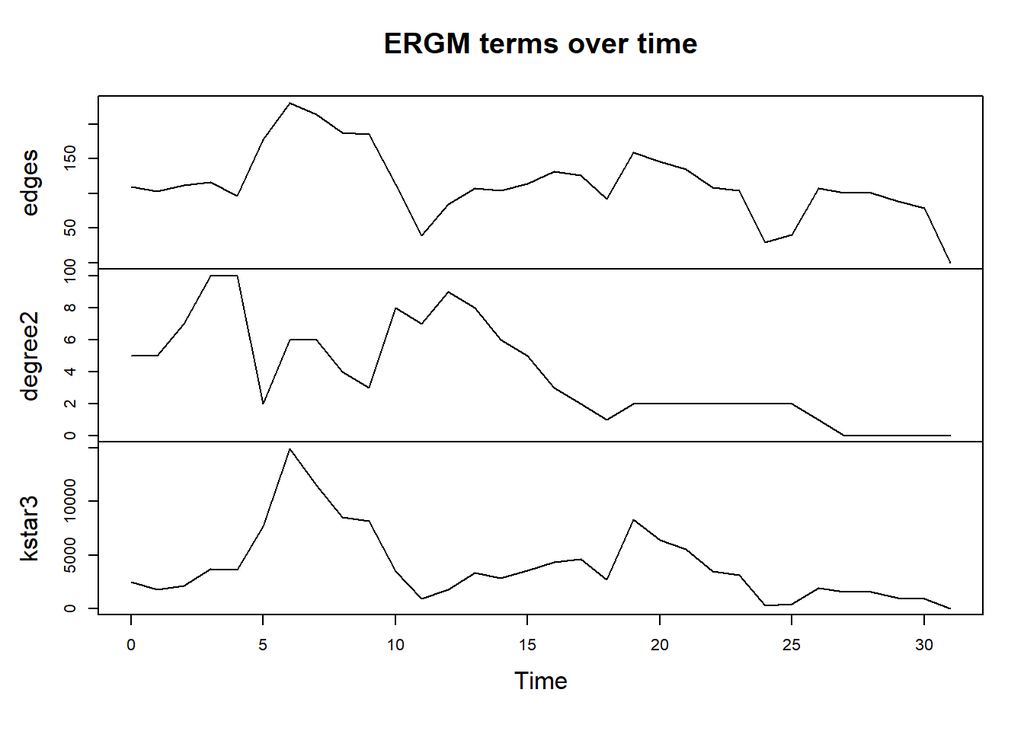

```r
data(windsurfers, package = "networkDynamic")

plot(tsna::tErgmStats(windsurfers,'~edges + degree(2) + kstar(3)',
                      aggregate.dur = 5), main = "ERGM terms over time")
```

In the lecture, we discussed *participation shifts*–also known as *p-shifts*. Gibson (2003) defined 13 P-shifts, and the `tsna::pShiftCount` function can count how often each type occurs in a specific time segment. This is how Gibson describes each of the thirteen types:

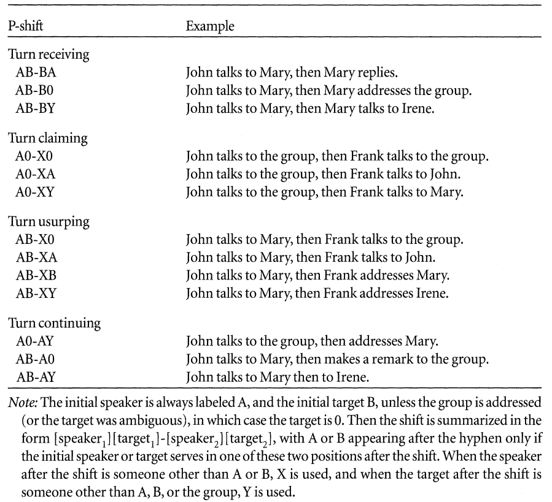

```r
knitr::include_graphics("pshifts.png")
```

### 10.2.3 Participation shifts

- `tsna::pShiftCount(g, start = 1, end = 3)` Calculates the number of times each of the above P-shifts occurred during the specified time segment. In other words, this calculates the *P-shift census*.

### 10.2.4 Temporal paths

The `tsna::tPath` function calculates the set of temporally reachable vertices from a given source vertex starting at a specific time.

- `tsna::tPath(g, v = 12, direction = "fwd", start = 0, end = 3)` This calculates the temporal paths from vertex 12 to all other vertices, from the start of the specified time segment. When `direction = "bkwd"`, it determines the paths *to* vertex 12. You can further specify whether you will find the paths that arrive the first or the ones that leave the vertex at the latest possible times.

The generally most relevant parts of the resulting object are:

- `tdist` The time each specific path takes. When a path does not exist, the value if Inf.
- `gsteps` The length of the path (in terms of the number of steps). When a path does not exist, the value if Inf.

The `tsna::plotPaths` plots the network and highlights the calculated temporal paths from the chosen vertex (vertex 12, in the example above). It can also add a label to each edge, so you can see how much time it takes for that edge to be activated from this focal vertex. You can tweak the plot like you would tweak any network plot of class `network`.

```r
tsna::plotPaths(
  g,
  paths = tsna::tPath(g, v = 12, direction = "fwd", start = 0, end = 3),
  displaylabels = FALSE,        # remove the vertex labels, to prevent too much visual clutter
  vertex.col = "white",
  edge.label.cex = 1.5          # the color of the printed times
)
```

A related concept is that of “temporal reachability.” The `tsna::tReach` function computes, for each vertex, the number of vertices that are temporally reachable over the entire observation period.<> If you want to compute this for a specific time segment, first use `networkDynamic::network.extract` to extract the segment of interest and then feed this to the `tsna::tReach` function.

- `tsna::tReach(g, direction = "fwd", start = 10, end = 20)` The function to calculate the temporal reachable sets using only temporally forward steps (you can also specify `direction = "bkwd"` to determine by how many vertices each vertex can be temporally reached).

## 10.3 Network visualization

Temporal networks can be visualized in two ways. First, static plots can be made of a temporal network, either by collapsing the temporal network into a static network (or to break up the temporal network into static networks of specific time segments).

### 10.3.1 Visualizing as static networks

An obvious way to visualize the entire temporal network as a static network is to simply use `plot(g)`.

Alternatively, the temporal network can be collapsed into smaller time segments and plot these the network slices as static representations.

There are two functions that can do this. The `ndtv` package has the

`ndtv::filmstrip` that does this as follows:

- `ndtv::filmstrip(g, frames = 9)` This plots the network at 9 points in time. It does *not* provide an overview of how the network changes over time, but it provides a series of snapshots (9, in this example) of the network. If the timing of the edges is in continuous time, this function has the tendency to plot nearly empty graphs, as it evaluates the networks at specific time *points*, rather than time *intervals*.

The `snafun` package implements a function that divides the specified time period into time segments of equal time length and plots each segment as a static network. This is useful to see how the network changes over time. It also works nicely for networks where changes happen in continuous time.

```r
snafun::plot_network_slices(9, number = 93)
```

A sometimes useful function is `ndtv::proximity.timeline`, which shows the distance between the edges over time. The main purpose is to see how the edges move vis-a-vis each other over time (based on the geodesic path distance) and it often helps to see where and when subgroups are forming over time.

The function call is:

```r
ndtv::proximity.timeline(g,  start = 10, end = 50,
                         time.increment = .5,
                         mode = 'isoMDS')
```

where you can change the *mode* to a different scaling algorithm. For actual research projects, you want to try various settings and check which gives you the most informative output for the data at hand.

The function allows you to set many arguments (such as labels and colors).

### 10.3.2 Visualizing as a dynamic network animation

The `ndtv` package includes functions to create an animation of how the network unfolds over time. There are many arguments you can tweak, so here we only focus on the main approach. Make sure to consult the package help for more details.

There are two steps in creating a dynamic visualization in `ndtv`: you first run `ndtv::compute.animation`, which determines coordinates and other aspects of the dynamic plot. Second, you run `ndtv::render.d3movie`, which, you guessed it, renders the actual movie.

```r
# step 0: unfortunately, we have to load the package into our session
library(ndtv)

# step 1: compute the settings
ndtv::compute.animation(g, animation.mode = "kamadakawai",
                        slice.par = list(start = 0, end = 45,
                                         aggregate.dur = 1,
                                         interval = 1, rule = "any"))

# step 2, render the animation
ndtv::render.d3movie(g, usearrows = TRUE, displaylabels = FALSE ,
                     bg = "#111111",
                     edge.col = "#55555599",
                     render.par = list(tween.frames = 15,
                                       show.time = TRUE),
                     d3.options = list(animationDuration = 1000,
                                       playControls = TRUE,
                                       durationControl = TRUE),
                     output.mode = 'htmlWidget'
                     )
```

Some important arguments for `ndtv::render.d3movie` include:

- `launchBrowser`: defaults to TRUE: determines whether the animation will be shown in the Browser after rendering.
- `output.mode`: the kind of output you want (defaults to ‘HTML’)
- `filename`: The file name of the HTML or JSON file to be generated. Only relevant if you picked ‘HTML’ or ‘JSON’ as output.mode.

Further, you can set most of the common graphical parameters, such as `vertex.col`, `label.cex`, `use.arrows`, `edge.lwd`, et cetera.

If you want to fix vertices to the same location throughout the animation, you do this as follows

```r
# use some way to determine a matrix of vertex locations
coords <- ndtv::network.layout.animate.kamadakawai(g)

# add the x and y coordinates as vertex attributes
# adapt onset and terminus if required
networkDynamic::activate.vertex.attribute(g, "x", coords[, 1],
                                          onset = -Inf, terminus = Inf)

networkDynamic::activate.vertex.attribute(g, "y", coords[, 2],
                                          onset = -Inf, terminus = Inf)

# compute the new animation settings
# We now use `animation.mode = "useAttribute"`
ndtv::compute.animation(g, animation.mode = "useAttribute",
                        slice.par = list(start = 0, end = 45,
                                         aggregate.dur = 1,
                                         interval = 1, rule = "any"))
```